# My visual data story

## My phone use?

I logged **50** phone use sessions from march 27 to march 30 and may 12 in 2026, recording the duration, purpose, and whether each session increase or decrease my productivity. Below here is some of the data:

50

Sessions logged

90 min

Average session duration

Work/Study

Most productivity increases

Entertainment

Most productivity decreases

## Does session purpose impact productivity?

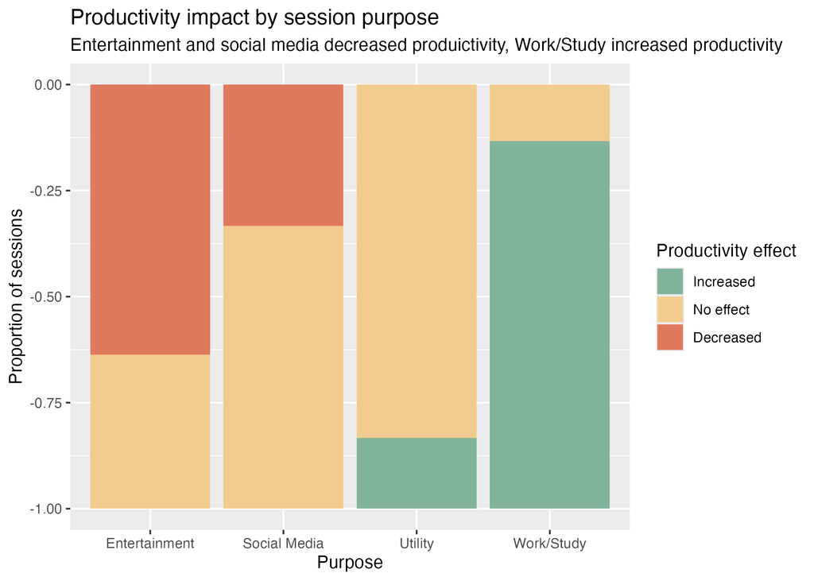

plot1

## Does session length matter?

Sessions under 50 minutes show little to no effect on productivity. It is the longer sessions where productivity starts to get affected. As the boxplot shown below:

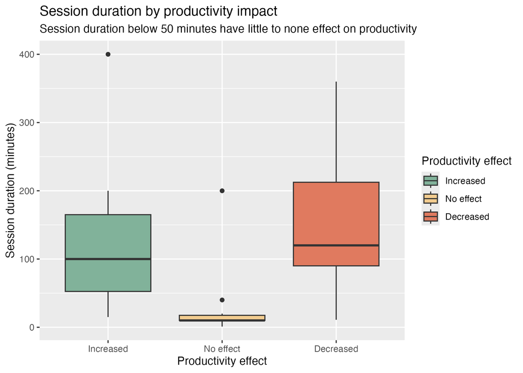

plot2

## When were sessions logged?

I usually log the sessions at 12pm and 4pm but this doesn’t change anything >_<.

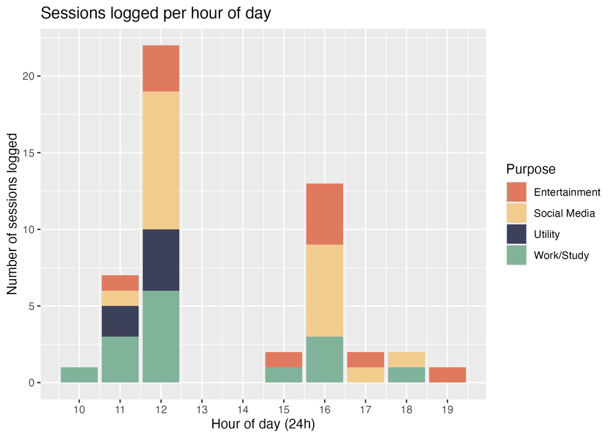

plot3

## How Phone Usage Affects Productivity in Daily Life

The pattern is clear that **Work/Study** would increased productivity, while **Entertainment** most often decreased it by distracting us from the things we needed to do. Short sessions under 50 minutes tend to be harmless regardless of purpose but as it get longer it will affect on our productivity and daily routines. We need to be aware of our screen time as it is important for maintaining balance in everyday life.